# WeRateDogs

## A deep dive into the popular twitter account

[figure not shown]

WeRateDogs is a verified twitter account that is extremely popular for rating and commenting about dogs submitted by their followers. Their unique rating system and humorous comments have garnered the twitter user a total of 9.3 million followers since the account's creation in November 2015. Their unique dog stages - pupper, puppos, doggos and floofers named based on their age and appearance also makes the account uniquely popular.

Influenced by their unique niche, we set out to analyze tweets by the account. The intention was to find out which is the most popular dog stage and if their unique rating system is responsible for the high number of retweets and favorites.

After retrieving, cleaning and analyzing over 2000 tweets, the general consensus is that the ratings seem to be unaffected by the number of retweets and likes a tweet gets. However, the higher the number of likes, the higher the likes and vice versa.

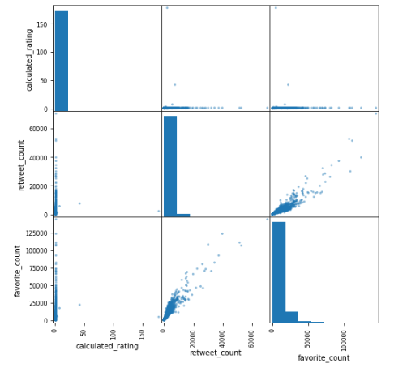

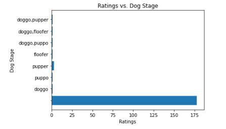

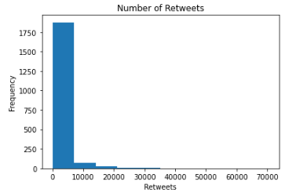

The account often goes viral based on the number of retweets that go as high as 70,000. Generally, the account seems to have a high engagement rate given that their tweets are mostly submissions from their followers. The high like and retweet count also indicate the massive reach of WeRateDogs.